# BDAT 608: Model Basics in R

Families, Fitting, Visualisation & Diagnostics

Department of Statistics & Actuarial Science, University of Ghana, Legon

2026-05-20

# 1 Prerequisites and Setup

## 1.1 What You Will Learn

This chapter covers the complete statistical modelling workflow in R:

1. **Define** a model family and a fitting criterion.
2. **Fit** the model using `lm()`, `glm()`, or custom optimisation.
3. **Visualise** fitted values and residuals to assess model adequacy.
4. **Extend** to non-linear, robust, and penalised models when the simple linear form is insufficient.
5. **Scale up** to many models simultaneously using `purrr::map()`, `tidyr::nest()`, and `broom::tidy()`.

The key insight from *R for Data Science* (Wickham & Grolemund, 2017): **a model separates signal from noise**. The fitted values capture the pattern; the residuals contain everything the model missed.

## 1.2 Package Installation

```r
# Run ONLY once. Keep commented during normal use.
install.packages(c(
  "tidyverse", "modelr", "ggfortify", "caret", "mice", "cvAUC",
  "mgcv", "rpart", "rpart.plot", "nycflights13", "MASS",
  "glmnet", "broom", "hexbin"
))
```

## 1.3 Load Libraries

```r
library(tidyverse)     # Data manipulation and visualisation
library(modelr)        # data_grid(), add_predictions(), add_residuals()
library(splines)       # ns() natural splines (ships with base R)
library(ggfortify)     # autoplot() diagnostics for lm objects
library(caret)         # createFolds() for cross-validation
library(mice)          # Multiple imputation for missing data
library(cvAUC)         # admissions dataset for logistic regression
library(mgcv)          # gam(), s(), te()
library(rpart)         # Decision tree models
library(rpart.plot)    # rpart.plot() better tree visualisation
library(nycflights13)  # flights dataset
library(MASS)          # rlm() robust regression
library(glmnet)        # Ridge and LASSO regression
library(broom)         # tidy(), augment(), glance() for model outputs

# MASS masks dplyr::select — restore the tidyverse versions explicitly
select <- dplyr::select
filter <- dplyr::filter
```

## 1.4 Global Options and Package Check

```r
# Warn when lm() silently drops rows with missing values
options(na.action = na.warn)

required_packages <- c(
  "tidyverse", "modelr", "ggfortify", "caret", "mice", "cvAUC",
  "mgcv", "rpart", "rpart.plot", "nycflights13", "MASS",
  "glmnet", "broom", "hexbin"
)
package_check <- sapply(required_packages, requireNamespace, quietly = TRUE)
print(package_check)
```

```
##    tidyverse       modelr    ggfortify        caret         mice        cvAUC
##         TRUE         TRUE         TRUE         TRUE         TRUE         TRUE
##         mgcv        rpart   rpart.plot nycflights13         MASS       glmnet
##         TRUE         TRUE         TRUE         TRUE         TRUE         TRUE
##        broom       hexbin
##         TRUE        FALSE
```

```r
if (any(!package_check)) {
  warning("Some packages are missing. Uncomment install.packages() above.")
}
```

## 1.5 Main Datasets

The following datasets are used throughout this chapter.

| Dataset | Package | Description |
| --- | --- | --- |
| `sim1` | `modelr` | Simple linear relationship |
| `sim2` | `modelr` | Categorical predictor |
| `sim3` | `modelr` | Continuous + categorical predictors |
| `sim4` | `modelr` | Two continuous predictors |
| `diamonds` | `ggplot2` | Diamond prices and characteristics |
| `flights` | `nycflights13` | NYC departure/arrival data |
| `admissions` | `cvAUC` | Graduate school admissions |

```r
data("sim1", package = "modelr")
sim1_base <- sim1   # keep a pristine copy before we add columns later

glimpse(sim1)
```

```
## Rows: 30
## Columns: 2
## $ x <int> 1, 1, 1, 2, 2, 2, 3, 3, 3, 4, 4, 4, 5, 5, 5, 6, 6, 6, 7, 7, 7, 8, 8,…
## $ y <dbl> 4.199913, 7.510634, 2.125473, 8.988857, 10.243105, 11.296823, 7.3563…
```

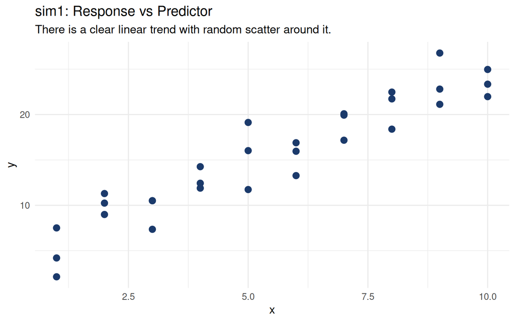

sim1: A simple linear relationship between x and y.

```r
ggplot(sim1, aes(x, y)) +
  geom_point(size = 3, colour = "#1B3A6B") +
  labs(
    title    = "sim1: Response vs Predictor",
    subtitle = "There is a clear linear trend with random scatter around it."
  ) +
  theme_minimal(base_size = 13)
```

# 2 Introduction to Statistical Models

## 2.1 What Is a Statistical Model?

A **statistical model** partitions observed data into two components:

$$y = \underbrace{f(x)}_{\text{signal
(systematic)}} + \underbrace{\varepsilon}_{\text{noise
(random)}}$$

- $f(x)$ is what we want to learn — the structural relationship between the predictors and the response.
- $\varepsilon$ is the irreducible noise — variation that no model can explain.

The modelling process involves choosing a plausible shape for $f$, estimating it from data, and checking whether the residuals $y - \hat{f}(x)$ look like noise.

## 2.2 Model Family vs Fitted Model

There are two conceptually distinct objects:

1. **Model family** — the *shape* of the equation, e.g. $y = a_0 + a_1 x$. This is the collection of all possible straight lines through any intercept and slope.
2. **Fitted model** — the *specific member* of that family that best matches the observed data, e.g. $\hat{y} = 4.22 + 2.05\,x$.

Choosing a model family is an assumption about the data-generating process. You cannot verify the assumption from the data alone, but you can diagnose whether it is reasonable by inspecting residuals.

## 2.3 The Modelling Workflow

The lecture follows this iterative cycle:

```
Observe Data  ──>  Choose Model Family  ──>  Define Fitting Criterion (e.g. RMSE)
       ^                                                     │
       │                                                     ▼
Revise Model  <──  Inspect Residuals  <──  Generate Predictions  <──  Fit Model
```

This cycle repeats until the residuals look like random noise — meaning the model has captured all available systematic variation in the data.

# 3 Fitting a Simple Linear Model

## 3.1 The Linear Model Family

For `sim1`, we hypothesise:

$$y = a_1 + a_2 \cdot x +
\varepsilon$$

where $a_1$ is the intercept and $a_2$ is the slope. The fitting problem is: **find $a_1$ and $a_2$ that make the line as close as possible to all data points simultaneously**.

## 3.2 Defining Candidate Models and the RMSE Loss Function

Before using built-in R functions, we build the loss function manually to understand what is being optimised.

```r
# Predicted y values for a given (intercept, slope) pair
model1 <- function(a, data) {
  a[1] + data$x * a[2]
}

# Root Mean Squared Error: the standard OLS criterion
# Smaller RMSE => the line fits the data better
measure_distance <- function(mod, data) {
  resid <- data$y - model1(mod, data)
  sqrt(mean(resid^2))
}

# Test a candidate model: intercept = 7, slope = 1.5
measure_distance(c(7, 1.5), sim1)
```

```
## [1] 2.665212
```

> **Why RMSE?** Squaring the residuals penalises large errors more heavily than small ones. Minimising RMSE is mathematically equivalent to **Ordinary Least Squares (OLS)**. The quadratic penalty is what makes OLS sensitive to outliers.

## 3.3 Mean Absolute Error (MAE): An Outlier-Resistant Alternative

MAE replaces squared residuals with absolute residuals:

$$\text{MAE} = \frac{1}{n}\sum_{i=1}^n
|y_i - \hat{y}_i|$$

Because errors are not squared, no single large residual dominates the criterion.

```r
measure_mae <- function(mod, data) {
  resid <- data$y - model1(mod, data)
  mean(abs(resid))
}

# Simulate data with heavy-tailed (Student-t, df=2) noise — prone to outliers
set.seed(42)
sim1a <- tibble(
  x = rep(1:10, each = 3),
  y = x * 1.5 + 6 + rt(length(x), df = 2)
)

best_mae <- optim(c(0, 0), measure_mae, data = sim1a)
ols_fit  <- lm(y ~ x, data = sim1a)

cat("MAE-optimal: intercept =", round(best_mae$par[1], 3),
    "  slope =", round(best_mae$par[2], 3), "\n")
```

```
## MAE-optimal: intercept = 6.314   slope = 1.496
```

```r
cat("OLS:         intercept =", round(coef(ols_fit)[1], 3),
    "  slope =", round(coef(ols_fit)[2], 3), "\n")
```

```
## OLS:         intercept = 7.318   slope = 1.294
```

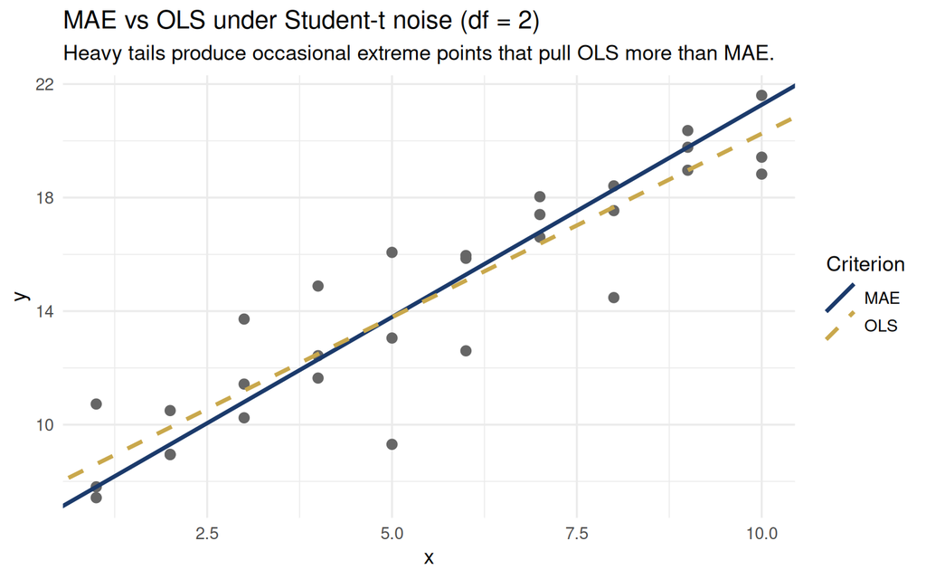

MAE vs OLS fitting under heavy-tailed noise. OLS is pulled toward extreme residuals; MAE is more stable.

```r
ggplot(sim1a, aes(x, y)) +
  geom_point(colour = "grey40", size = 2.5) +
  geom_abline(aes(intercept = best_mae$par[1], slope = best_mae$par[2],
                  colour = "MAE"), linewidth = 1.2) +
  geom_abline(aes(intercept = coef(ols_fit)[1],  slope = coef(ols_fit)[2],
                  colour = "OLS"), linewidth = 1.2, linetype = "dashed") +
  scale_colour_manual(values = c("MAE" = "#1B3A6B", "OLS" = "#C9A84C")) +
  labs(
    title    = "MAE vs OLS under Student-t noise (df = 2)",
    subtitle = "Heavy tails produce occasional extreme points that pull OLS more than MAE.",
    colour   = "Criterion"
  ) +
  theme_minimal(base_size = 13)
```

> **Interpretation:** Under heavy-tailed noise, OLS is pulled away from the bulk of the data because it squares residuals. MAE weighs all errors on the absolute scale and is therefore more resistant to outliers — it gives estimates closer to the true generating line.

## 3.4 Random Search Over the Parameter Space

It is instructive to generate many random candidate lines, rank them by RMSE, and visualise the best few. This shows geometrically what “fitting” means.

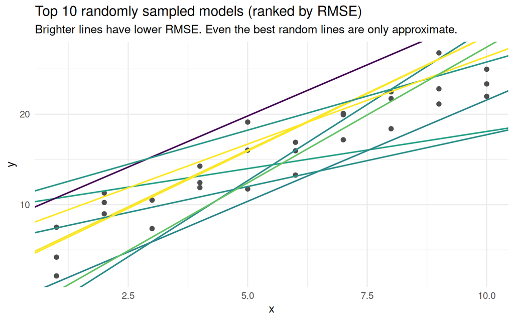

Top 10 randomly sampled lines on sim1, coloured by quality (brighter = lower RMSE).

```r
sim1_dist <- function(a1, a2) measure_distance(c(a1, a2), sim1)

set.seed(7)
models <- tibble(
  a1 = runif(250, -20, 40),
  a2 = runif(250, -5, 5)
) |>
  mutate(dist = purrr::map2_dbl(a1, a2, sim1_dist))

ggplot(sim1, aes(x, y)) +
  geom_point(size = 2, colour = "grey30") +
  geom_abline(
    aes(intercept = a1, slope = a2, colour = -dist),
    data      = filter(models, rank(dist) <= 10),
    linewidth = 0.8
  ) +
  scale_colour_viridis_c(guide = "none") +
  labs(
    title    = "Top 10 randomly sampled models (ranked by RMSE)",
    subtitle = "Brighter lines have lower RMSE. Even the best random lines are only approximate."
  ) +
  theme_minimal(base_size = 13)
```

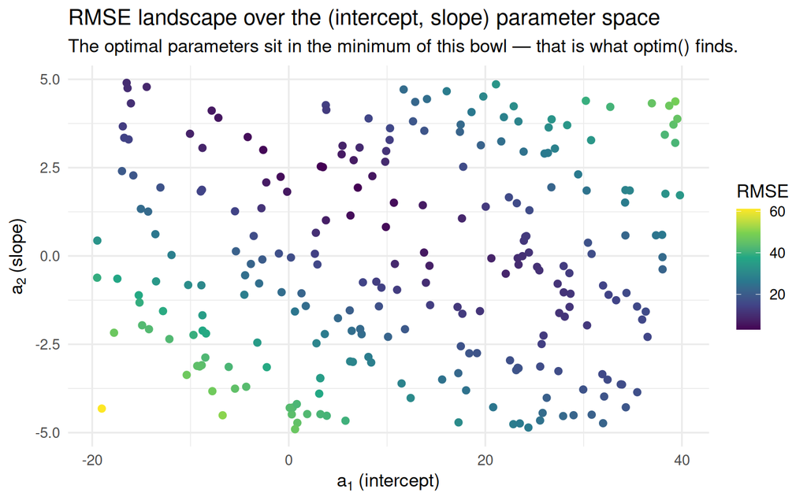

```r
ggplot(models, aes(a1, a2, colour = dist)) +
  geom_point(size = 2) +
  scale_colour_viridis_c(name = "RMSE") +
  labs(
    title    = "RMSE landscape over the (intercept, slope) parameter space",
    subtitle = "The optimal parameters sit in the minimum of this bowl — that is what optim() finds.",
    x        = expression(a[1] ~ "(intercept)"),
    y        = expression(a[2] ~ "(slope)")
  ) +
  theme_minimal(base_size = 13)
```

## 3.5 Grid Search

A grid search evaluates RMSE on a structured, evenly spaced grid of parameter values. More systematic than random search but becomes prohibitively expensive as the number of parameters grows.

```r
grid_search <- expand.grid(
  a1 = seq(-5, 20, length = 25),
  a2 = seq(1,   3,  length = 25)
) |>
  mutate(dist = purrr::map2_dbl(a1, a2, sim1_dist))

grid_search |> slice_min(dist, n = 5)
```

```
##         a1       a2     dist
## 1 4.375000 2.000000 2.137234
## 2 4.375000 2.083333 2.155409
## 3 3.333333 2.166667 2.168677
## 4 5.416667 1.916667 2.210294
## 5 3.333333 2.250000 2.212637
```

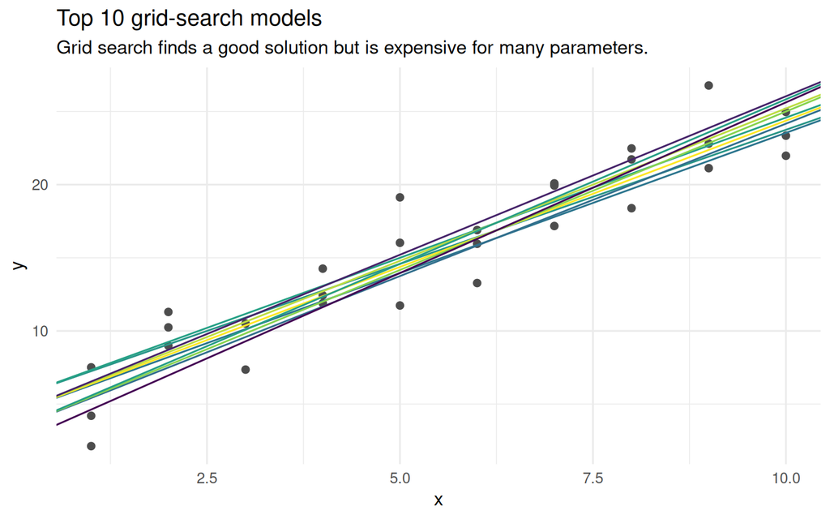

Top 10 grid-search models. The structured grid covers the space more evenly than random sampling.

```r
ggplot(sim1, aes(x, y)) +
  geom_point(size = 2, colour = "grey30") +
  geom_abline(
    aes(intercept = a1, slope = a2, colour = -dist),
    data = filter(grid_search, rank(dist) <= 10)
  ) +
  scale_colour_viridis_c(guide = "none") +
  labs(
    title    = "Top 10 grid-search models",
    subtitle = "Grid search finds a good solution but is expensive for many parameters."
  ) +
  theme_minimal(base_size = 13)
```

## 3.6 Numerical Optimisation with `optim()`

`optim()` uses an iterative algorithm (default: Nelder-Mead simplex) to locate the parameter values that minimise any user-supplied function. It is more efficient than exhaustive search and generalises to any smooth loss.

```r
best <- optim(
  par  = c(0, 0),
  fn   = measure_distance,
  data = sim1
)

cat("Best intercept:", round(best$par[1], 4), "\n")
```

```
## Best intercept: 4.2222
```

```r
cat("Best slope:    ", round(best$par[2], 4), "\n")
```

```
## Best slope:     2.0512
```

```r
cat("Minimum RMSE:  ", round(best$value,  4), "\n")
```

```
## Minimum RMSE:   2.1282
```

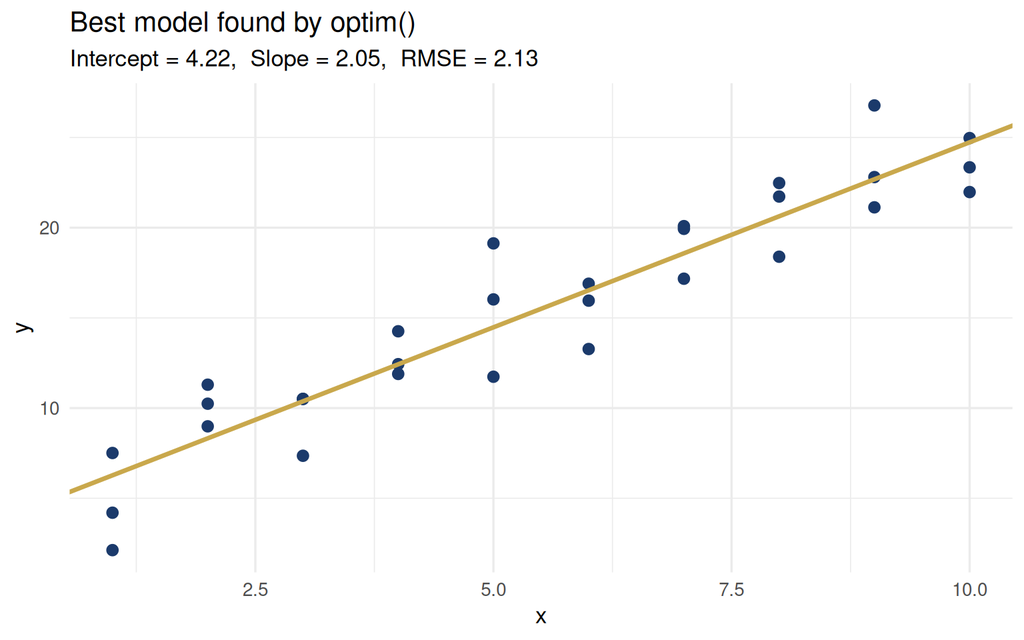

Best model found by optim() on sim1.

```r
ggplot(sim1, aes(x, y)) +
  geom_point(colour = "#1B3A6B", size = 2.5) +
  geom_abline(
    intercept = best$par[1],
    slope     = best$par[2],
    colour    = "#C9A84C",
    linewidth = 1.2
  ) +
  labs(
    title    = "Best model found by optim()",
    subtitle = paste0("Intercept = ", round(best$par[1], 2),
                      ",  Slope = ",  round(best$par[2], 2),
                      ",  RMSE = ",   round(best$value,  2))
  ) +
  theme_minimal(base_size = 13)
```

## 3.7 Closed-Form OLS with `lm()`

For the ordinary linear model, the OLS solution has a closed form:

$$\hat{\boldsymbol{\beta}} =
\bigl(\mathbf{X}^\top \mathbf{X}\bigr)^{-1} \mathbf{X}^\top
\mathbf{y}$$

`lm()` computes this via numerically stable QR decomposition — faster and more reliable than `optim()` for standard linear models.

```r
sim1_mod <- lm(y ~ x, data = sim1)
coef(sim1_mod)
```

```
## (Intercept)           x
##    4.220822    2.051533
```

```r
summary(sim1_mod)
```

```
##
## Call:
## lm(formula = y ~ x, data = sim1)
##
## Residuals:
##     Min      1Q  Median      3Q     Max
## -4.1469 -1.5197  0.1331  1.4670  4.6516
##
## Coefficients:
##             Estimate Std. Error t value Pr(>|t|)
## (Intercept)   4.2208     0.8688   4.858 4.09e-05 ***
## x             2.0515     0.1400  14.651 1.17e-14 ***
## ---
## Signif. codes:  0 '***' 0.001 '**' 0.01 '*' 0.05 '.' 0.1 ' ' 1
##
## Residual standard error: 2.203 on 28 degrees of freedom
## Multiple R-squared:  0.8846, Adjusted R-squared:  0.8805
## F-statistic: 214.7 on 1 and 28 DF,  p-value: 1.173e-14
```

# 4 Visualising Models

Good modelling practice requires you to look at what the model produces, not just the coefficient table. The `modelr` package provides a consistent set of helpers that work with any model that has a `predict()` method.

## 4.1 Generating Predictions with `modelr`

`data_grid()` creates an evenly spaced grid of predictor values spanning the observed range. `add_predictions()` appends the model’s fitted values to that grid.

```r
grid <- sim1 |>
  data_grid(x) |>
  add_predictions(sim1_mod)

print(grid)
```

```
## # A tibble: 10 × 2
##        x  pred
##    <int> <dbl>
##  1     1  6.27
##  2     2  8.32
##  3     3 10.4
##  4     4 12.4
##  5     5 14.5
##  6     6 16.5
##  7     7 18.6
##  8     8 20.6
##  9     9 22.7
## 10    10 24.7
```

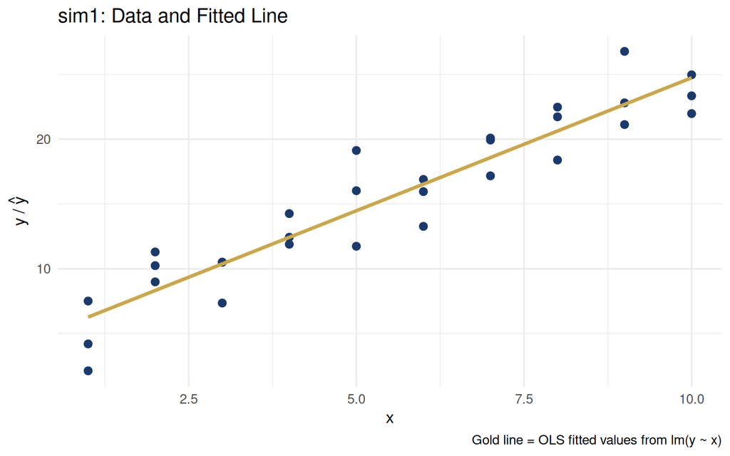

Observed data (blue) and OLS fitted line (gold) from sim1.

```r
ggplot(sim1, aes(x)) +
  geom_point(aes(y = y), colour = "#1B3A6B", size = 2.5) +
  geom_line(aes(y = pred), data = grid, colour = "#C9A84C", linewidth = 1.3) +
  labs(
    title   = "sim1: Data and Fitted Line",
    y       = expression(y ~ "/" ~ hat(y)),
    caption = "Gold line = OLS fitted values from lm(y ~ x)"
  ) +
  theme_minimal(base_size = 13)
```

## 4.2 Adding and Plotting Residuals

$$\text{residual}_i = y_i -
\hat{y}_i$$

Residuals represent what the model did **not** explain. A well-specified model produces residuals that:

- are **centred around zero** (no systematic bias),
- show **no pattern against predictors** (no remaining structure), and
- are **roughly normally distributed** (for valid standard errors and p-values).

```r
sim1 <- sim1 |> add_residuals(sim1_mod)
```

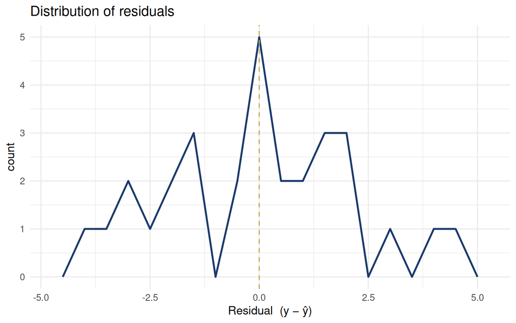

Distribution of residuals: symmetric and centred at zero, as expected for a correctly specified model.

```r
ggplot(sim1, aes(resid)) +
  geom_freqpoly(binwidth = 0.5, colour = "#1B3A6B", linewidth = 1) +
  geom_vline(xintercept = 0, linetype = "dashed", colour = "#C9A84C") +
  labs(
    title = "Distribution of residuals",
    x     = "Residual  (y − ŷ)"
  ) +
  theme_minimal(base_size = 13)
```

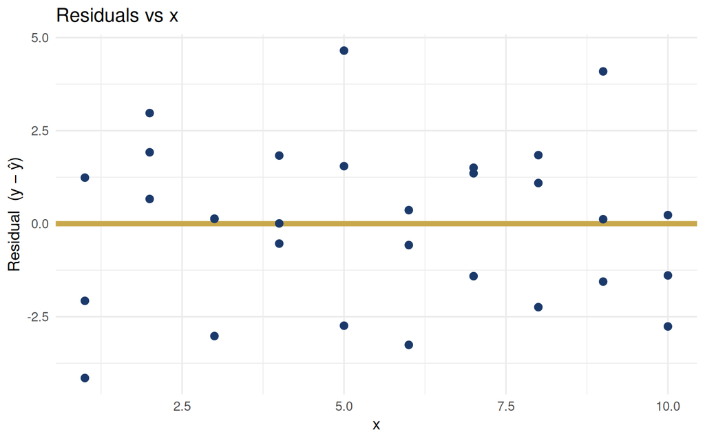

Residuals vs x. Random scatter around zero confirms the linear model is correctly specified.

```r
ggplot(sim1, aes(x, resid)) +
  geom_ref_line(h = 0, colour = "#C9A84C") +
  geom_point(colour = "#1B3A6B", size = 2.5) +
  labs(
    title = "Residuals vs x",
    y     = "Residual  (y − ŷ)"
  ) +
  theme_minimal(base_size = 13)
```

> **Interpretation:** Residuals are randomly scattered around zero with no visible curve or fan shape. This confirms that (a) the linear mean is correctly specified and (b) variance is approximately constant across the range of $x$. If a curve were visible, we would need to add a non-linear term; if spread increased with $x$, we would need a variance-stabilising transformation.

## 4.3 Standard Diagnostic Plots

Base R’s `plot.lm()` produces four key diagnostics in a 2×2 grid:

| Plot | What It Shows | Ideal Appearance |
| --- | --- | --- |
| Residuals vs Fitted | Non-linearity, heteroscedasticity | Random horizontal band around 0 |
| Normal Q-Q | Normality of residuals | Points on the 45° diagonal |
| Scale-Location | Homoscedasticity (constant variance) | Flat red loess line |
| Cook’s Distance | Influential observations | No point much greater than 1 |

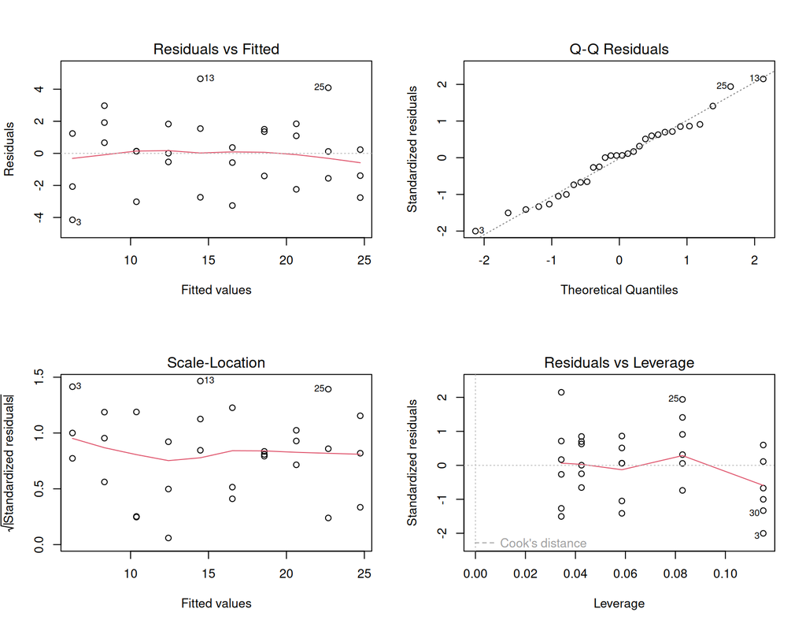

Base R 2×2 diagnostic panel for the sim1 OLS model.

```r
par(mfrow = c(2, 2))
plot(sim1_mod)
```

```r
par(mfrow = c(1, 1))
```

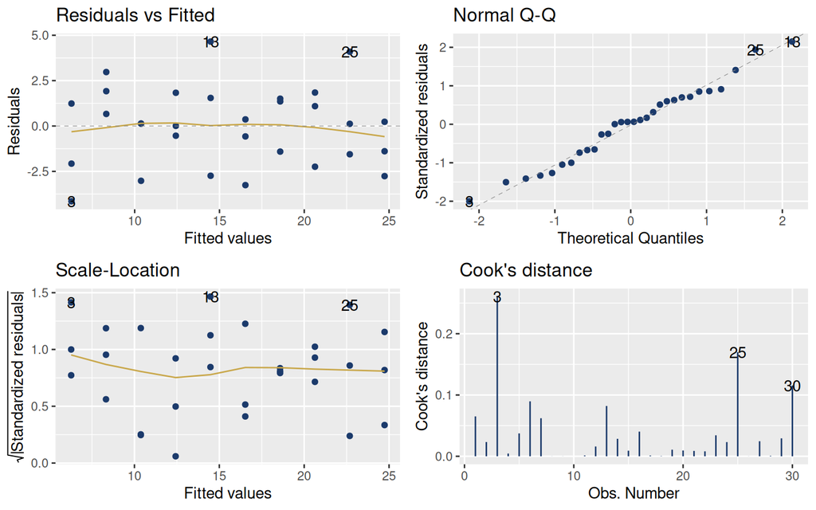

ggplot2-style diagnostics via ggfortify::autoplot().

```r
autoplot(
  sim1_mod,
  which         = 1:4,
  colour        = "#1B3A6B",
  smooth.colour = "#C9A84C"
)
```

## 4.4 Comparing Multiple Models

`gather_predictions()` and `gather_residuals()` stack predictions or residuals from multiple models into a single long data frame — ideal for faceted comparison plots.

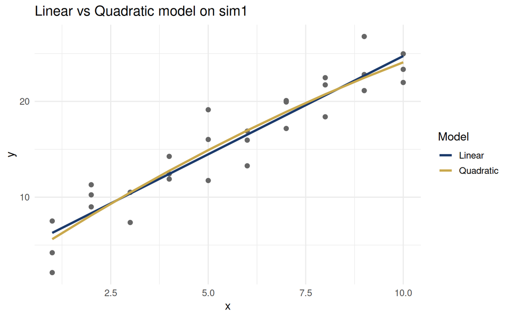

Linear vs quadratic model on sim1. The quadratic adds negligible improvement here.

```r
mod_a <- lm(y ~ x,          data = sim1)
mod_b <- lm(y ~ x + I(x^2), data = sim1)

grid_multi <- sim1 |>
  data_grid(x) |>
  gather_predictions(mod_a, mod_b)

ggplot(sim1, aes(x, y)) +
  geom_point(colour = "grey40", size = 2) +
  geom_line(data = grid_multi, aes(y = pred, colour = model), linewidth = 1.2) +
  scale_colour_manual(
    values = c("#1B3A6B", "#C9A84C"),
    labels = c("Linear", "Quadratic")
  ) +
  labs(title = "Linear vs Quadratic model on sim1", colour = "Model") +
  theme_minimal(base_size = 13)
```

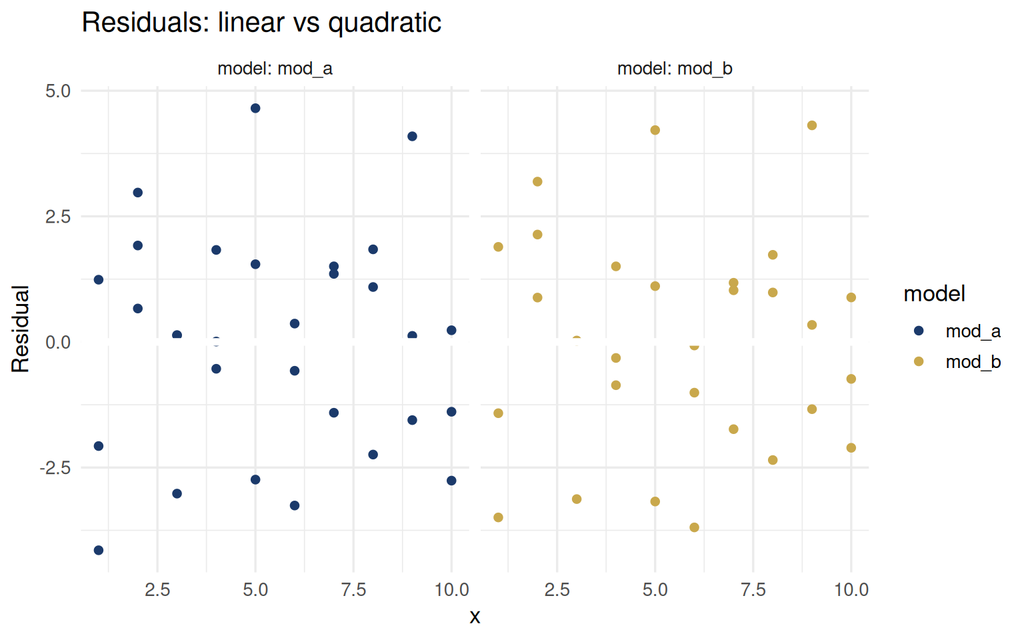

Residuals side-by-side. For sim1, both models leave similar residual patterns — the quadratic term is not needed.

```r
sim1 |>
  gather_residuals(mod_a, mod_b) |>
  ggplot(aes(x, resid, colour = model)) +
  geom_point() +
  geom_ref_line(h = 0) +
  facet_wrap(~ model, labeller = label_both) +
  scale_colour_manual(values = c("#1B3A6B", "#C9A84C")) +
  labs(title = "Residuals: linear vs quadratic", y = "Residual") +
  theme_minimal(base_size = 13)
```

# 5 Formulas and Model Families

R uses a compact **formula notation** to specify the structure of a model. Understanding this notation is essential for `lm()`, `glm()`, `gam()`, and virtually every other modelling function.

## 5.1 Formula Notation and the Model Matrix

The formula `y ~ x1 + x2` tells R to fit $y = \beta_0 + \beta_1 x_1 + \beta_2 x_2 + \varepsilon$. R automatically includes an intercept column of ones. Use `model_matrix()` to inspect the exact design matrix produced.

```r
df <- tribble(
  ~y, ~x1, ~x2,
  4,   2,   5,
  5,   1,   6
)

model_matrix(df, y ~ x1)          # intercept added automatically
```

```
## # A tibble: 2 × 2
##   `(Intercept)`    x1
##           <dbl> <dbl>
## 1             1     2
## 2             1     1
```

```r
model_matrix(df, y ~ x1 - 1)      # remove intercept
```

```
## # A tibble: 2 × 1
##      x1
##   <dbl>
## 1     2
## 2     1
```

```r
model_matrix(df, y ~ x1 + x2)     # two predictors
```

```
## # A tibble: 2 × 3
##   `(Intercept)`    x1    x2
##           <dbl> <dbl> <dbl>
## 1             1     2     5
## 2             1     1     6
```

**Common formula operators:**

| Operator | Meaning | Example |
| --- | --- | --- |
| `+` | Add predictor | `y ~ x1 + x2` |
| `-` | Remove term | `y ~ x1 + x2 - 1` |
| `*` | Interaction + main effects | `y ~ x1 * x2` |
| `:` | Interaction only | `y ~ x1 + x2 + x1:x2` |
| `I()` | Arithmetic (protected) | `y ~ I(x^2)` |
| `poly()` | Polynomial terms | `y ~ poly(x, 3)` |
| `ns()` | Natural spline | `y ~ ns(x, 5)` |

## 5.2 Categorical Predictors and Dummy Coding

When a predictor is categorical (a `factor`), R automatically creates **dummy variables** — one binary column per level, minus one for the reference level. The reference level’s mean becomes the intercept; each dummy coefficient is the *difference* from that reference.

```r
data("sim2", package = "modelr")
glimpse(sim2)
```

```
## Rows: 40
## Columns: 2
## $ x <chr> "a", "a", "a", "a", "a", "a", "a", "a", "a", "a", "b", "b", "b", "b"…
## $ y <dbl> 1.9353632, 1.1764886, 1.2436855, 2.6235489, 1.1120381, 0.8660030, -0…
```

```r
mod2 <- lm(y ~ x, data = sim2)
model_matrix(sim2, y ~ x) |> head(8)   # inspect dummy encoding
```

```
## # A tibble: 8 × 4
##   `(Intercept)`    xb    xc    xd
##           <dbl> <dbl> <dbl> <dbl>
## 1             1     0     0     0
## 2             1     0     0     0
## 3             1     0     0     0
## 4             1     0     0     0
## 5             1     0     0     0
## 6             1     0     0     0
## 7             1     0     0     0
## 8             1     0     0     0
```

```r
coef(mod2)
```

```
## (Intercept)          xb          xc          xd
##   1.1521664   6.9638728   4.9750241   0.7588142
```

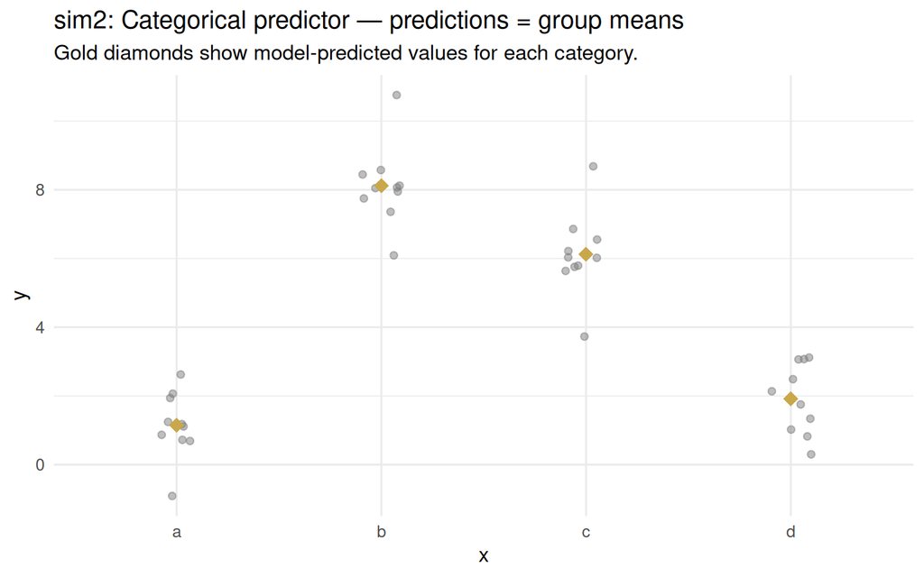

For a categorical predictor, OLS predictions equal the group means (gold diamonds).

```r
preds_cat <- sim2 |>
  data_grid(x) |>
  add_predictions(mod2)

ggplot(sim2, aes(x, y)) +
  geom_jitter(colour = "grey50", width = 0.1, alpha = 0.5) +
  geom_point(data = preds_cat, aes(y = pred),
             colour = "#C9A84C", size = 4, shape = 18) +
  labs(
    title    = "sim2: Categorical predictor — predictions = group means",
    subtitle = "Gold diamonds show model-predicted values for each category."
  ) +
  theme_minimal(base_size = 13)
```

> **Interpretation:** Under OLS, the predicted value for each category exactly equals the sample mean of that group. The intercept is the reference group mean; each dummy coefficient is the deviation of that group’s mean from the reference.

## 5.3 Interaction: Continuous × Categorical Predictor

`sim3` has a continuous predictor `x1` and a four-level categorical predictor `x2`.

- **Additive model** (`y ~ x1 + x2`): one common slope for all groups, different intercepts.
- **Interaction model** (`y ~ x1 * x2`): both slopes and intercepts differ across groups.

`x1 * x2` expands to `x1 + x2 + x1:x2` — main effects plus all pairwise interactions.

```r
data("sim3", package = "modelr")
glimpse(sim3)
```

```
## Rows: 120
## Columns: 5
## $ x1  <int> 1, 1, 1, 1, 1, 1, 1, 1, 1, 1, 1, 1, 2, 2, 2, 2, 2, 2, 2, 2, 2, 2, …
## $ x2  <fct> a, a, a, b, b, b, c, c, c, d, d, d, a, a, a, b, b, b, c, c, c, d, …
## $ rep <int> 1, 2, 3, 1, 2, 3, 1, 2, 3, 1, 2, 3, 1, 2, 3, 1, 2, 3, 1, 2, 3, 1, …
## $ y   <dbl> -0.5707363, 1.1841503, 2.2373204, 7.4366963, 8.5182934, 7.7239098,…
## $ sd  <dbl> 2, 2, 2, 2, 2, 2, 2, 2, 2, 2, 2, 2, 2, 2, 2, 2, 2, 2, 2, 2, 2, 2, …
```

```r
mod_add <- lm(y ~ x1 + x2,  data = sim3)   # parallel lines
mod_int <- lm(y ~ x1 * x2,  data = sim3)   # different slopes per group

model_matrix(sim3, y ~ x1 * x2) |> names()
```

```
## [1] "(Intercept)" "x1"          "x2b"         "x2c"         "x2d"
## [6] "x1:x2b"      "x1:x2c"      "x1:x2d"
```

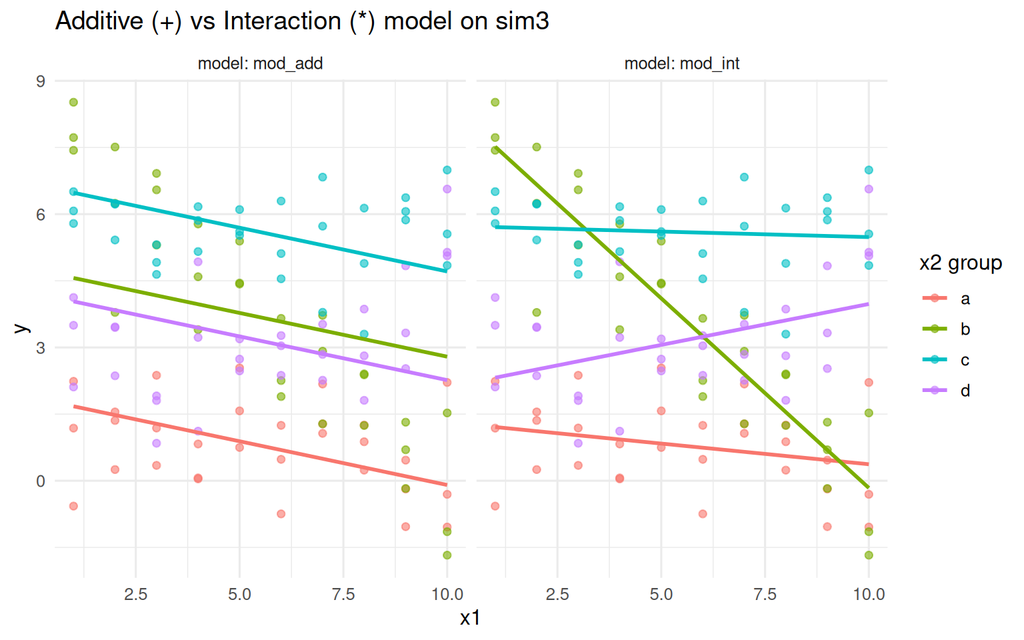

Additive (+) vs interaction (*) model on sim3. With interaction, slopes can differ by group.

```r
grid_sim3 <- sim3 |>
  data_grid(x1, x2) |>
  gather_predictions(mod_add, mod_int)

ggplot(sim3, aes(x1, y, colour = x2)) +
  geom_point(alpha = 0.6) +
  geom_line(data = grid_sim3, aes(y = pred), linewidth = 1) +
  facet_wrap(~ model, labeller = label_both) +
  labs(
    title  = "Additive (+) vs Interaction (*) model on sim3",
    colour = "x2 group"
  ) +
  theme_minimal(base_size = 12)
```

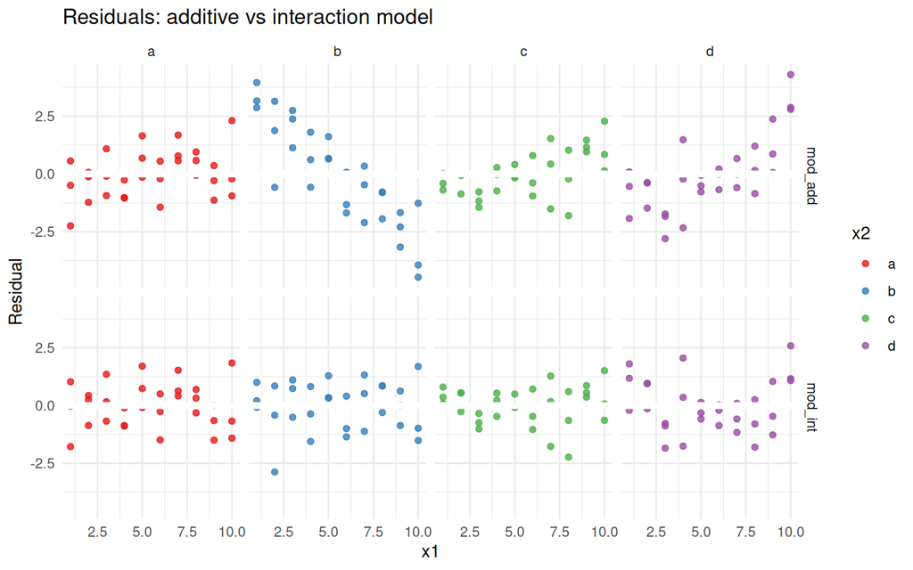

Residuals by group and model. Remaining patterns in the additive model indicate that slopes vary by group.

```r
sim3 |>
  gather_residuals(mod_add, mod_int) |>
  ggplot(aes(x1, resid, colour = x2)) +
  geom_point(alpha = 0.8) +
  geom_ref_line(h = 0) +
  facet_grid(model ~ x2) +
  scale_colour_brewer(palette = "Set1") +
  labs(
    title = "Residuals: additive vs interaction model",
    y     = "Residual"
  ) +
  theme_minimal(base_size = 11)
```

```r
AIC(mod_add, mod_int)
```

```
##         df      AIC
## mod_add  6 449.9045
## mod_int  9 356.0336
```

```r
cat("Additive R²:   ", round(summary(mod_add)$r.squared, 4), "\n")
```

```
## Additive R²:    0.5911
```

```r
cat("Interaction R²:", round(summary(mod_int)$r.squared, 4), "\n")
```

```
## Interaction R²: 0.8221
```

> **Interpretation:** The interaction model has lower AIC and higher $R^2$. The residual plot for the additive model shows systematic patterns within certain groups (the slopes differ), whereas the interaction model residuals are more uniformly scattered. Prefer the interaction model when the slope of a continuous predictor varies across groups.

## 5.4 Interaction: Two Continuous Predictors

`sim4` has two continuous predictors. The interaction term `x1 * x2` allows the slope of `x1` to depend on the value of `x2` (and vice versa).

```r
data("sim4", package = "modelr")
glimpse(sim4)
```

```
## Rows: 300
## Columns: 4
## $ x1  <dbl> -1, -1, -1, -1, -1, -1, -1, -1, -1, -1, -1, -1, -1, -1, -1, -1, -1…
## $ x2  <dbl> -1.0000000, -1.0000000, -1.0000000, -0.7777778, -0.7777778, -0.777…
## $ rep <int> 1, 2, 3, 1, 2, 3, 1, 2, 3, 1, 2, 3, 1, 2, 3, 1, 2, 3, 1, 2, 3, 1, …
## $ y   <dbl> 4.24767769, 1.20599701, 0.35347770, -0.04665814, 4.63868987, 1.377…
```

```r
mod1_s4 <- lm(y ~ x1 + x2,  data = sim4)   # additive: parallel planes
mod2_s4 <- lm(y ~ x1 * x2,  data = sim4)   # interaction: twisted plane

AIC(mod1_s4, mod2_s4)
```

```
##         df      AIC
## mod1_s4  4 1304.461
## mod2_s4  5 1296.040
```

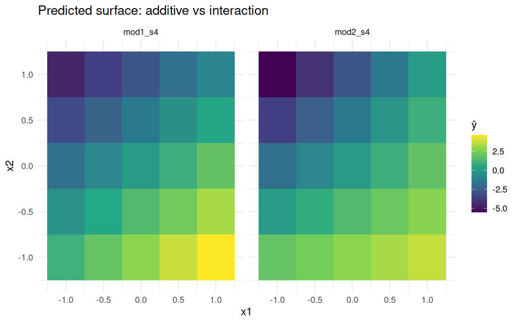

Predicted surface: additive model (parallel planes) vs interaction model (twisted/curved surface).

```r
grid4 <- sim4 |>
  data_grid(
    x1 = seq_range(x1, n = 5),
    x2 = seq_range(x2, n = 5)
  ) |>
  gather_predictions(mod1_s4, mod2_s4)

ggplot(grid4, aes(x1, x2, fill = pred)) +
  geom_tile() +
  facet_wrap(~ model) +
  scale_fill_viridis_c() +
  labs(title = "Predicted surface: additive vs interaction", fill = "ŷ") +
  theme_minimal(base_size = 12)
```

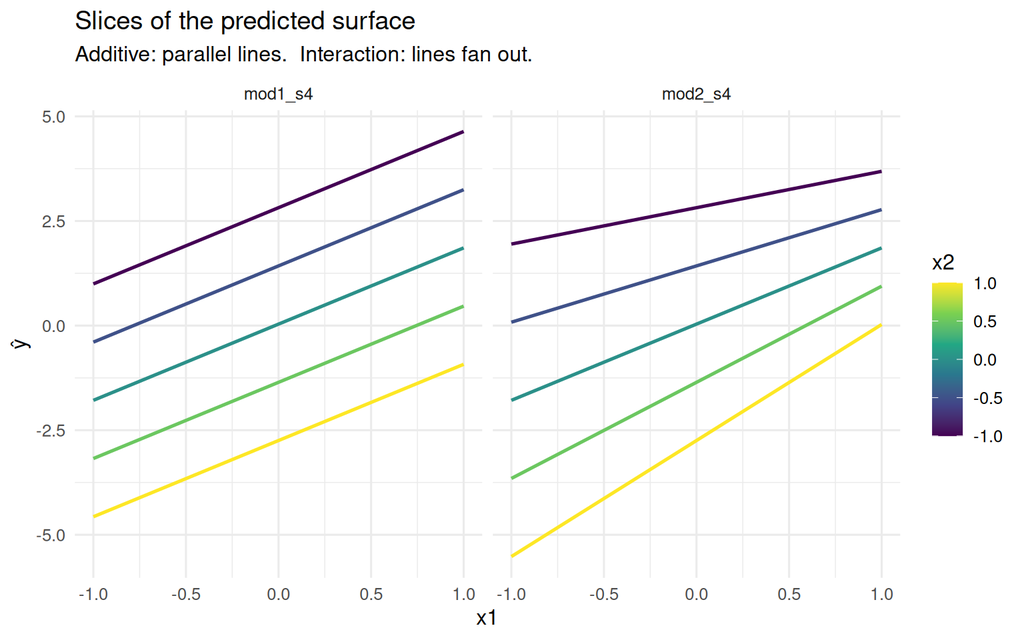

Slice view: each line is a fixed value of x2. Parallel lines = no interaction; fanning lines = interaction present.

```r
ggplot(grid4, aes(x1, pred, colour = x2, group = x2)) +
  geom_line(linewidth = 0.9) +
  facet_wrap(~ model) +
  scale_colour_viridis_c() +
  labs(
    title    = "Slices of the predicted surface",
    subtitle = "Additive: parallel lines.  Interaction: lines fan out.",
    y        = "ŷ",
    colour   = "x2"
  ) +
  theme_minimal(base_size = 12)
```

> **Interpretation:** In the additive model the lines are **parallel** — the effect of `x1` is identical regardless of `x2`. In the interaction model the lines **fan out** — the slope of `x1` increases with `x2`. The heatmap shows this as a gradient diagonal in the interaction panel.

## 5.5 Extended Example: Three-Way Interaction

This example demonstrates how to test whether an interaction term itself differs across groups using sequential ANOVA.

```r
set.seed(99)
n <- 200

df3 <- tibble(
  x1    = rnorm(n),
  x2    = rnorm(n),
  group = sample(c("A", "B"), n, replace = TRUE),
  # Group B has an x1*x2 interaction; group A does not
  y     = 2 * x1 + 1.5 * x2 +
          ifelse(group == "B", 3 * x1 * x2, 0) +
          rnorm(n, sd = 0.8)
)

m0 <- lm(y ~ x1 + x2 + group,         data = df3)  # no interaction
m1 <- lm(y ~ x1 * x2 + group,         data = df3)  # x1:x2, same in all groups
m2 <- lm(y ~ x1 * x2 * group,         data = df3)  # three-way term

anova(m0, m1, m2)
```

```
## Analysis of Variance Table
##
## Model 1: y ~ x1 + x2 + group
## Model 2: y ~ x1 * x2 + group
## Model 3: y ~ x1 * x2 * group
##   Res.Df    RSS Df Sum of Sq      F    Pr(>F)
## 1    196 908.59
## 2    195 569.42  1    339.17 529.96 < 2.2e-16 ***
## 3    192 122.88  3    446.54 232.58 < 2.2e-16 ***
## ---
## Signif. codes:  0 '***' 0.001 '**' 0.01 '*' 0.05 '.' 0.1 ' ' 1
```

> **Interpretation:** `anova()` performs sequential likelihood-ratio F-tests. Both the $x_1 \times x_2$ interaction and the three-way term are significant because the data were generated with group-specific interaction effects — group B has an $x_1 \cdot x_2$ interaction that group A does not.

## 5.6 Transformations Inside Formulas

In R formulas, `^` is a **formula operator** (variable crossing), not arithmetic exponentiation. Use `I()` to shield literal arithmetic from the formula parser.

```r
# WRONG: R collapses x^2 + x to just x — only ONE column
model_matrix(sim1_base, y ~ x^2 + x) |> head(3)
```

```
## # A tibble: 3 × 2
##   `(Intercept)`     x
##           <dbl> <dbl>
## 1             1     1
## 2             1     1
## 3             1     1
```

```r
# CORRECT: I() protects the exponentiation — TWO distinct columns
model_matrix(sim1_base, y ~ I(x^2) + x) |> head(3)
```

```
## # A tibble: 3 × 3
##   `(Intercept)` `I(x^2)`     x
##           <dbl>    <dbl> <dbl>
## 1             1        1     1
## 2             1        1     1
## 3             1        1     1
```

```r
# Log transformation of the response (log-linear model)
lm(log(y) ~ x, data = sim1_base)
```

```
##
## Call:
## lm(formula = log(y) ~ x, data = sim1_base)
##
## Coefficients:
## (Intercept)            x
##      1.7307       0.1625
```

```r
# Square-root transformation of the predictor
lm(y ~ sqrt(x), data = sim1_base)
```

```
##
## Call:
## lm(formula = y ~ sqrt(x), data = sim1_base)
##
## Coefficients:
## (Intercept)      sqrt(x)
##      -4.202        8.771
```

```r
# Multiple transformations in one formula
lm(log(y) ~ I(x^2) + x, data = sim1_base)
```

```
##
## Call:
## lm(formula = log(y) ~ I(x^2) + x, data = sim1_base)
##
## Coefficients:
## (Intercept)       I(x^2)            x
##     1.28762     -0.02014      0.38407
```

> **Warning:** Without `I()`, `y ~ x^2 + x` is silently treated as `y ~ x`. Always verify your model matrix with `model_matrix()` when in doubt.

## 5.7 Polynomial Models with `poly()`

Polynomial regression extends the linear model to capture curvature. `poly(x, d)` produces $d$ polynomial columns.

- **Default:** orthogonal polynomials — numerically stable, but coefficients are hard to interpret directly.
- **`raw = TRUE`:** ordinary power terms $x, x^2, \ldots, x^d$ — interpretable but correlated columns.

```r
# Raw polynomial: readable coefficients
mod_p2 <- lm(y ~ poly(x, 2, raw = TRUE), data = sim1_base)
coef(mod_p2)
```

```
##             (Intercept) poly(x, 2, raw = TRUE)1 poly(x, 2, raw = TRUE)2
##              3.02244913              2.65071947             -0.05447149
```

```r
# Compare fits across polynomial degrees
mods <- list(
  p1 = lm(y ~ poly(x, 1), data = sim1_base),
  p2 = lm(y ~ poly(x, 2), data = sim1_base),
  p3 = lm(y ~ poly(x, 3), data = sim1_base),
  p5 = lm(y ~ poly(x, 5), data = sim1_base)
)
```

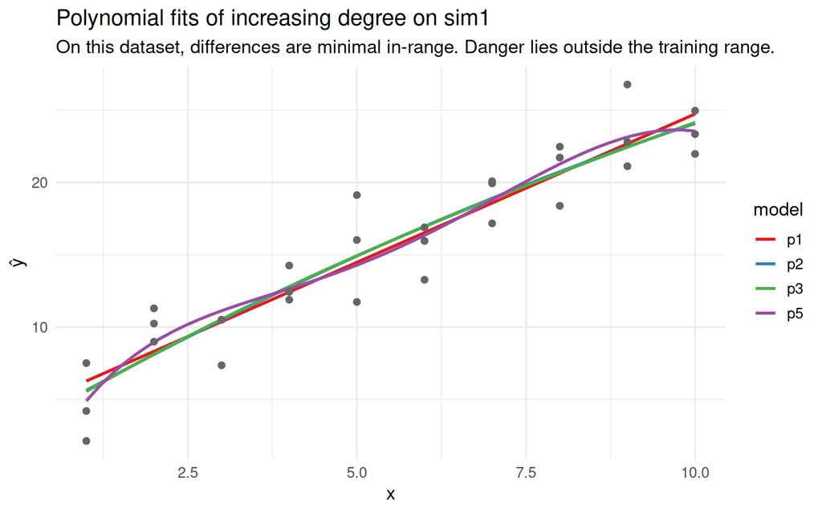

Polynomial fits of degrees 1–5 on sim1. All degrees give similar in-range fits; divergence would appear outside the data.

```r
sim1_base |>
  data_grid(x = seq_range(x, 50)) |>
  gather_predictions(!!!mods) |>
  ggplot(aes(x, pred, colour = model)) +
  geom_line(linewidth = 1) +
  geom_point(data = sim1_base, aes(x, y), colour = "grey40", inherit.aes = FALSE) +
  scale_colour_brewer(palette = "Set1") +
  labs(
    title    = "Polynomial fits of increasing degree on sim1",
    subtitle = "On this dataset, differences are minimal in-range. Danger lies outside the training range.",
    y        = "ŷ"
  ) +
  theme_minimal(base_size = 13)
```

> **Interpretation:** Higher-degree polynomials fit the training data better but **extrapolate dangerously** — they shoot to $\pm\infty$ outside the data range. Natural splines provide flexible non-linear fitting without this problem.